# E-commerce Analysis

This analysis is focused on extracting actionable and relevant knowledge out of the dataset provided. You can find the main metrics of the e-commerce regarding sales and revenue from 2010-12 to 2011-12.

```python
import pandas as pd
import numpy as np
import datetime as dt
import seaborn as sns
import matplotlib.pyplot as plt
sns.set(style="ticks")
```

```python
# Load the file
```

```python
data = pd.read_csv('data.csv', encoding='unicode_escape')
data.head()
```

|  | InvoiceNo | StockCode | Description | Quantity | InvoiceDate | UnitPrice | CustomerID | Country |
| --- | --- | --- | --- | --- | --- | --- | --- | --- |
| 0 | 536365 | 85123A | WHITE HANGING HEART T-LIGHT HOLDER | 6 | 12/1/2010 8:26 | 2.55 | 17850.0 | United Kingdom |
| 1 | 536365 | 71053 | WHITE METAL LANTERN | 6 | 12/1/2010 8:26 | 3.39 | 17850.0 | United Kingdom |
| 2 | 536365 | 84406B | CREAM CUPID HEARTS COAT HANGER | 8 | 12/1/2010 8:26 | 2.75 | 17850.0 | United Kingdom |
| 3 | 536365 | 84029G | KNITTED UNION FLAG HOT WATER BOTTLE | 6 | 12/1/2010 8:26 | 3.39 | 17850.0 | United Kingdom |
| 4 | 536365 | 84029E | RED WOOLLY HOTTIE WHITE HEART. | 6 | 12/1/2010 8:26 | 3.39 | 17850.0 | United Kingdom |

### Assumptions:

- Remove duplicates records;
- Get only records when Revenue > 0;
- For the same InvoiceNo(order), Description, InvoiceDate, CustomerID, and Country, we sum all quantities and revenues (having the same StockCode or not). Below, you can see an example when StockeCode varies for the same InvoiceNo:

```python
data[(data.InvoiceNo == '547083') & (data.Description == 'COLUMBIAN CANDLE RECTANGLE')]
```

|  | InvoiceNo | StockCode | Description | Quantity | InvoiceDate | UnitPrice | CustomerID | Country |
| --- | --- | --- | --- | --- | --- | --- | --- | --- |
| 126530 | 547083 | 72133 | COLUMBIAN CANDLE RECTANGLE | 1 | 3/20/2011 15:21 | 1.25 | 15452.0 | United Kingdom |
| 126531 | 547083 | 72131 | COLUMBIAN CANDLE RECTANGLE | 1 | 3/20/2011 15:21 | 1.95 | 15452.0 | United Kingdom |
| 126533 | 547083 | 72133 | COLUMBIAN CANDLE RECTANGLE | 4 | 3/20/2011 15:21 | 1.25 | 15452.0 | United Kingdom |

```python
# Check and delete duplicates
```

```python
len(data[data.duplicated(['InvoiceNo', 'StockCode', 'Description', 'Quantity', 'InvoiceDate', 'UnitPrice', 'CustomerID', 'Country'])])
```

```
5268
```

```python
data.drop_duplicates(inplace=True)
```

```python
len(data[data.duplicated(['InvoiceNo', 'StockCode', 'Description', 'Quantity', 'InvoiceDate', 'UnitPrice', 'CustomerID', 'Country'])])
```

```
0
```

```python
# Add new columns: Revenue and InvoiceDateMonth
# Get only records where Revenue > 0
# Fill NaNs with 'None'
```

```python
data['Revenue'] = data['UnitPrice'] * data['Quantity']
data = data[data.Revenue > 0]
data = data.fillna('None')

data['InvoiceDateMonth'] = pd.to_datetime(data['InvoiceDate']).dt.to_period('M')
data.InvoiceDateMonth = data.InvoiceDateMonth.astype(str)
data.head()
```

|  | InvoiceNo | StockCode | Description | Quantity | InvoiceDate | UnitPrice | CustomerID | Country | Revenue | InvoiceDateMonth |
| --- | --- | --- | --- | --- | --- | --- | --- | --- | --- | --- |
| 0 | 536365 | 85123A | WHITE HANGING HEART T-LIGHT HOLDER | 6 | 12/1/2010 8:26 | 2.55 | 17850 | United Kingdom | 15.30 | 2010-12 |
| 1 | 536365 | 71053 | WHITE METAL LANTERN | 6 | 12/1/2010 8:26 | 3.39 | 17850 | United Kingdom | 20.34 | 2010-12 |
| 2 | 536365 | 84406B | CREAM CUPID HEARTS COAT HANGER | 8 | 12/1/2010 8:26 | 2.75 | 17850 | United Kingdom | 22.00 | 2010-12 |
| 3 | 536365 | 84029G | KNITTED UNION FLAG HOT WATER BOTTLE | 6 | 12/1/2010 8:26 | 3.39 | 17850 | United Kingdom | 20.34 | 2010-12 |
| 4 | 536365 | 84029E | RED WOOLLY HOTTIE WHITE HEART. | 6 | 12/1/2010 8:26 | 3.39 | 17850 | United Kingdom | 20.34 | 2010-12 |

## Analysis:

### What is the total revenue per month?

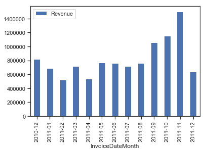

```python
revenue_per_month = data.groupby(['InvoiceDateMonth'])['Revenue'].sum().reset_index()
revenue_per_month.plot.bar(x='InvoiceDateMonth', y='Revenue')
```

In November, the company had a peak with more than 1.4M in revenue. However, in the following month (2011-12), the revenue dropped 58%. Also, we have a drop of 22% YoY (Year over Year) for December.

### What is the top 10 sold products?

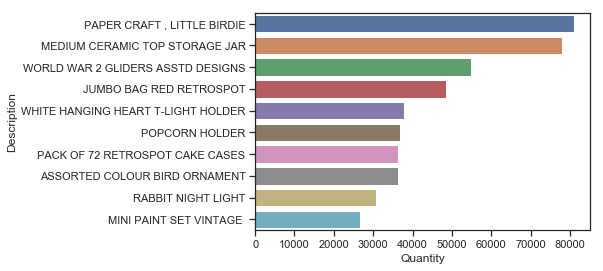

```python
items = data.groupby(['Description'])['Quantity', 'Revenue'].sum().reset_index().sort_values('Quantity', ascending=False)

ax = sns.barplot(x="Quantity", y="Description", data=items.head(10))
plt.show()
```

```python
# Contribution to the revenue of the top 2 products
```

```python
items[items.Description.isin(items.head(2).Description)].Revenue.sum() / items.Revenue.sum()
```

```
0.023507603388791022
```

"PAPER CRAFT , LITTLE BIRDIE" and "MEDIUM CERAMIC TOP STORAGE JAR" are the top 2 sold products overall. They correspond together 2% of the company total revenue.

### What is the top 10 countries in revenue?

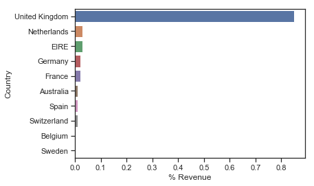

```python
revenue_per_country = data.groupby(['Country'])['Revenue'].sum().reset_index().sort_values('Revenue', ascending=False)
revenue_per_country['Total'] = revenue_per_country.Revenue.sum()
revenue_per_country['% Revenue'] = round(revenue_per_country.Revenue / revenue_per_country.Total,2)
top_10 = revenue_per_country[['Country', '% Revenue']].head(10)
ax = sns.barplot(x="% Revenue", y="Country", data=top_10)
plt.show()
```

United Kingdom contributes with 85% of the company revenue. Each of the other countries contribute no more than 3%.

### What is the revenue per month for UK? And for other countries?

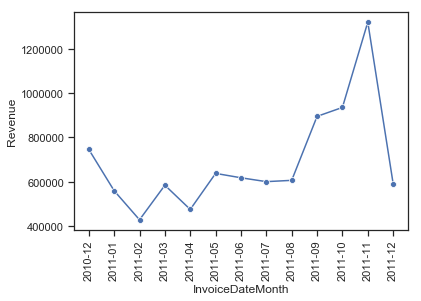

```python
UK = data[data.Country == 'United Kingdom']
UK_revenue_per_month = UK.groupby(['InvoiceDateMonth'])['Revenue'].sum().reset_index()

ax = sns.lineplot(x="InvoiceDateMonth", y="Revenue", marker="o", data=UK_revenue_per_month)
ax.set_xticklabels(labels=UK_revenue_per_month.InvoiceDateMonth.values, rotation=90)

plt.show()
```

As United Kingdom is the biggest market of the company, the revenue per month from there is very close to the revenue per month overall. In December, the revenue dropped around 55% and 21% YoY.

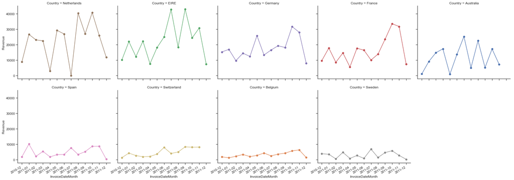

```python
other_countries = data[(data.Country.isin(top_10.Country)) & (data.Country != 'United Kingdom')]

others_revenue_per_month = other_countries.groupby(['InvoiceDateMonth', 'Country'])['Revenue'].sum().reset_index()

grid = sns.FacetGrid(others_revenue_per_month, col="Country", hue="Country", height=5, col_wrap=5, col_order=top_10[top_10.Country != 'United Kingdom'].Country)
grid.map(plt.plot, "InvoiceDateMonth", "Revenue", marker="o")

grid.fig.autofmt_xdate()
plt.show()
```

Other countries of the top 10, like Netherlands and EIRE (Ireland), have the max revenue per month around 40k. UK has the min revenue per month 10 times more (around 400k).

**As United Kingdom is the main market, all analysis bellow refers only to this country.**

### What is the number of orders per month for UK?

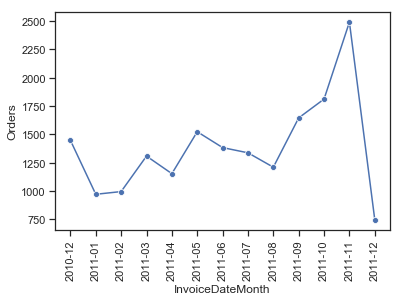

```python
UK_orders_per_month = UK.groupby(['InvoiceDateMonth'])['InvoiceNo'].nunique().reset_index().rename(columns={'InvoiceNo':'Orders'})

ax = sns.lineplot(x="InvoiceDateMonth", y="Orders", marker="o", data=UK_orders_per_month)
ax.set_xticklabels(labels=UK_orders_per_month.InvoiceDateMonth.values, rotation=90)

plt.show()
```

The number of orders had a peak in November, with almost 2500 orders. In December, this number dropped drastically, around 70% and 48% YoY.

### What is the average order value (AOV) per month for UK?

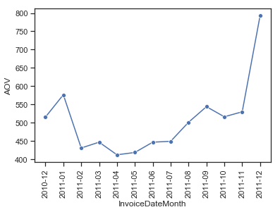

```python
UK_AOV = UK.groupby('InvoiceDateMonth').agg({"Revenue": np.sum, "InvoiceNo": pd.Series.nunique}).reset_index()
UK_AOV['AOV'] = UK_AOV.Revenue / UK_AOV.InvoiceNo

ax = sns.lineplot(x="InvoiceDateMonth", y="AOV", marker="o", data=UK_AOV)
ax.set_xticklabels(labels=UK_AOV.InvoiceDateMonth.values, rotation=90)

plt.show()
```

Even though the AOV is the highest one in December, the amount of revenue and orders dropped considerably. But as the number of orders dropped even more, so the AOV increased in December.

### What is the number of sold products per month for UK?

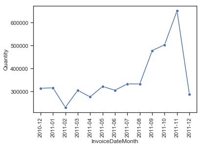

```python
UK_items_per_month = UK.groupby(['InvoiceDateMonth'])['Quantity'].sum().reset_index()

ax = sns.lineplot(x="InvoiceDateMonth", y="Quantity", marker="o", data=UK_items_per_month)
ax.set_xticklabels(labels=UK_items_per_month.InvoiceDateMonth.values, rotation=90)

plt.show()
```

In November the company had a peak in sales, with more than 650k products sold. However, in the next month, this number dropped around 56% and 8% YoY.

### What is the top 10 sold products for UK?

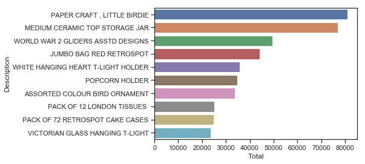

```python
UK_items = UK.groupby(['Description'])['Quantity', 'Revenue'].sum().reset_index().sort_values('Quantity', ascending=False).rename(columns={'Quantity':'Total'})

ax = sns.barplot(x="Total", y="Description", data=UK_items.head(10))
plt.show()
```

```python
# Contribution to the UK revenue of the top 6 products
```

```python
UK_items[UK_items.Description.isin(UK_items.head(6).Description)].Revenue.sum()/UK_items.Revenue.sum()
```

```
0.05340766244626374
```

The top 6 sold products overall is the same top 6 sold products for UK. The contribution of them together is around 5% of the UK revenue.

### Top 10 sold products per month for UK

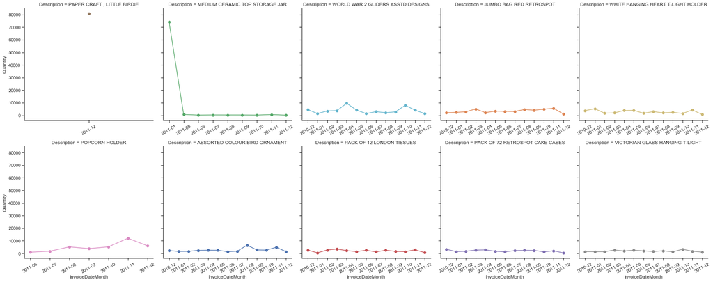

```python
UK_total_per_month = UK.groupby(['Description', 'InvoiceDateMonth'])['Quantity'].sum().reset_index()
UK_total_per_month = UK_total_per_month[UK_total_per_month.Description.isin(UK_items.Description.head(10))]

grid = sns.FacetGrid(UK_total_per_month, col="Description", hue="Description", height=5, col_wrap=5, sharex=False, col_order=UK_items.Description.head(10))
grid.map(plt.plot, "InvoiceDateMonth", "Quantity", marker="o")

for i, ax in enumerate(grid.fig.axes):   ## getting all axes of the fig object
    ax.set_xticklabels(ax.get_xticklabels(), rotation = 30)

grid.fig.tight_layout()
plt.show()
```

Even though "PAPER CRAFT , LITTLE BIRDIE" and "MEDIUM CERAMIC TOP STORAGE JAR" are the top 2 sold products, the big sold amount happened only in a certain month, not continuously. The amount of the second product dropped around 99% in sales for the following month. The other 8 remaining products keep the performance more consistent.

### What is the top 10 products in 2011-11 for UK?

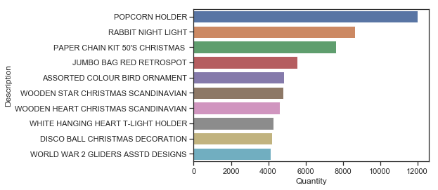

```python
UK_nov = UK[UK.InvoiceDateMonth == '2011-11']
UK_top_10_nov = UK_nov.groupby(['Description'])['Quantity'].sum().reset_index().sort_values('Quantity', ascending=False).head(10)

ax = sns.barplot(x="Quantity", y="Description", data=UK_top_10_nov)
plt.show()
```

As in November the company had a peak of sales, above, you can see the top 10 sold products in this particular month. "POPCORN HOLDER" appears as the top 1 and is also one of the top 10 sold products for UK and overall (6th). Also, based on the type of the products, seems people were more interested in Christmas shopping in November.

### Contribution to the revenue for new and returned users in UK

```python
UK_users = UK.groupby(['InvoiceDateMonth', 'CustomerID'])['Revenue'].sum().reset_index()
UK_users['rank'] = UK_users.groupby(['CustomerID'])['InvoiceDateMonth'].cumcount() + 1
```

```python
UK_new_users = UK_users[UK_users['rank'] == 1]
UK_new_users = UK_new_users.groupby(['InvoiceDateMonth']).agg({"Revenue": np.sum, "CustomerID": pd.Series.nunique}).rename(columns={'Revenue':'NewUsersRevenue', 'CustomerID':'NewUsersCount'}).reset_index()

UK_new_users.head()
```

|  | InvoiceDateMonth | NewUsersRevenue | NewUsersCount |
| --- | --- | --- | --- |
| 0 | 2010-12 | 746082.220 | 816 |
| 1 | 2011-01 | 241759.640 | 358 |
| 2 | 2011-02 | 135617.820 | 340 |
| 3 | 2011-03 | 169860.080 | 419 |
| 4 | 2011-04 | 110046.951 | 277 |

```python
UK_returned_users = UK_users[UK_users['rank'] != 1]
UK_returned_users = UK_returned_users.groupby(['InvoiceDateMonth']).agg({"Revenue": np.sum, "CustomerID": pd.Series.nunique}).rename(columns={'Revenue':'ReturnedUsersRevenue', 'CustomerID':'ReturnedUsersCount'}).reset_index()
UK_returned_users.head()
```

|  | InvoiceDateMonth | ReturnedUsersRevenue | ReturnedUsersCount |
| --- | --- | --- | --- |
| 0 | 2011-01 | 318216.19 | 290 |
| 1 | 2011-02 | 293368.80 | 340 |
| 2 | 2011-03 | 414950.70 | 462 |
| 3 | 2011-04 | 365630.68 | 508 |
| 4 | 2011-05 | 543410.79 | 707 |

```python
UK_perc_users = pd.merge(UK_new_users, UK_returned_users, on='InvoiceDateMonth')

UK_perc_users['TotalRevenue'] = UK_perc_users.NewUsersRevenue + UK_perc_users.ReturnedUsersRevenue
UK_perc_users['TotalUsers'] = UK_perc_users.NewUsersCount + UK_perc_users.ReturnedUsersCount
UK_perc_users['% New Users Revenue'] = UK_perc_users.NewUsersRevenue / UK_perc_users.TotalRevenue
UK_perc_users['% Returned Users Revenue'] = 1 - UK_perc_users['% New Users Revenue']

UK_perc_users
```

|  | InvoiceDateMonth | NewUsersRevenue | NewUsersCount | ReturnedUsersRevenue | ReturnedUsersCount | TotalRevenue | TotalUsers | % New Users Revenue | % Returned Users Revenue |
| --- | --- | --- | --- | --- | --- | --- | --- | --- | --- |
| 0 | 2011-01 | 241759.640 | 358 | 318216.190 | 290 | 559975.830 | 648 | 0.431732 | 0.568268 |
| 1 | 2011-02 | 135617.820 | 340 | 293368.800 | 340 | 428986.620 | 680 | 0.316135 | 0.683865 |
| 2 | 2011-03 | 169860.080 | 419 | 414950.700 | 462 | 584810.780 | 881 | 0.290453 | 0.709547 |
| 3 | 2011-04 | 110046.951 | 277 | 365630.680 | 508 | 475677.631 | 785 | 0.231348 | 0.768652 |
| 4 | 2011-05 | 94694.100 | 256 | 543410.790 | 707 | 638104.890 | 963 | 0.148399 | 0.851601 |
| 5 | 2011-06 | 107286.070 | 214 | 511059.460 | 676 | 618345.530 | 890 | 0.173505 | 0.826495 |
| 6 | 2011-07 | 61348.671 | 169 | 539570.400 | 691 | 600919.071 | 860 | 0.102091 | 0.897909 |
| 7 | 2011-08 | 56534.360 | 141 | 550250.570 | 694 | 606784.930 | 835 | 0.093170 | 0.906830 |
| 8 | 2011-09 | 137100.541 | 276 | 757998.101 | 871 | 895098.642 | 1147 | 0.153168 | 0.846832 |
| 9 | 2011-10 | 138342.650 | 324 | 797061.490 | 907 | 935404.140 | 1231 | 0.147896 | 0.852104 |
| 10 | 2011-11 | 117535.480 | 297 | 1202398.590 | 1209 | 1319934.070 | 1506 | 0.089046 | 0.910954 |
| 11 | 2011-12 | 24406.560 | 34 | 567213.180 | 527 | 591619.740 | 561 | 0.041254 | 0.958746 |

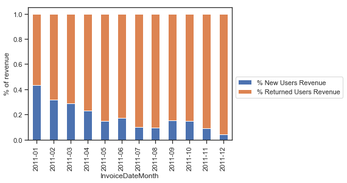

```python
UK_perc_users[['InvoiceDateMonth', '% New Users Revenue', '% Returned Users Revenue']].plot(x='InvoiceDateMonth', kind='bar', stacked=True).legend(bbox_to_anchor=(1.0, 0.5))
plt.ylabel('% of revenue')
plt.show()
```

Returned users contribute more to the revenue than new users for the entire period. For the last three months, the contribution to the revenue for the returned users is increasing.

### Number of new and returned users per month for UK

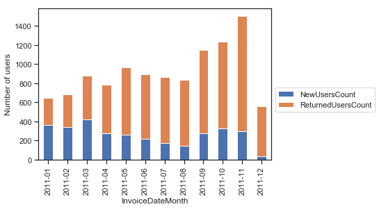

```python
UK_perc_users[['InvoiceDateMonth', 'NewUsersCount', 'ReturnedUsersCount']].plot(x='InvoiceDateMonth', kind='bar', stacked=True).legend(bbox_to_anchor=(1.0, 0.5))
plt.ylabel('Number of users')
plt.show()
```

Even though the returned users contribute more with the revenue for all months, in January and February were the only months where the number of returned users was not greater than new users. Also, the number of total users dropped around 63% in December.

### How much money do we make per customer per month on average for UK?

```python
UK_perc_users['AvgRevenuePerCustomer'] = UK_perc_users.TotalRevenue / UK_perc_users.TotalUsers

UK_perc_users.head()
```

|  | InvoiceDateMonth | NewUsersRevenue | NewUsersCount | ReturnedUsersRevenue | ReturnedUsersCount | TotalRevenue | TotalUsers | % New Users Revenue | % Returned Users Revenue | AvgRevenuePerCustomer |
| --- | --- | --- | --- | --- | --- | --- | --- | --- | --- | --- |
| 0 | 2011-01 | 241759.640 | 358 | 318216.19 | 290 | 559975.830 | 648 | 0.431732 | 0.568268 | 864.160231 |
| 1 | 2011-02 | 135617.820 | 340 | 293368.80 | 340 | 428986.620 | 680 | 0.316135 | 0.683865 | 630.862676 |
| 2 | 2011-03 | 169860.080 | 419 | 414950.70 | 462 | 584810.780 | 881 | 0.290453 | 0.709547 | 663.803383 |
| 3 | 2011-04 | 110046.951 | 277 | 365630.68 | 508 | 475677.631 | 785 | 0.231348 | 0.768652 | 605.958766 |
| 4 | 2011-05 | 94694.100 | 256 | 543410.79 | 707 | 638104.890 | 963 | 0.148399 | 0.851601 | 662.621900 |

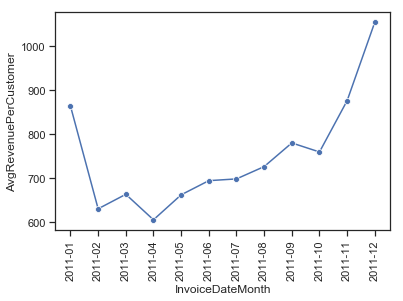

```python
ax = sns.lineplot(x="InvoiceDateMonth", y="AvgRevenuePerCustomer", marker="o", data=UK_perc_users)
ax.set_xticklabels(labels=UK_perc_users.InvoiceDateMonth.values, rotation=90)

plt.show()
```

In December, as the number of users dropped more than revenue amount, around 63% and 55% respectively, the company had the increase of average revenue per customer in this month.

## Conclusion:

- The company's performance is growing over time but dropps considerably in December. This seems a seasonal effect but the performance in December of previous year is a bit better;
- In November, the company had a peak in sales with more than 1.4M in revenue;
- United Kingdom (UK) is the main market. It contributes to 85% of the company revenue;
- UK has the min revenue per month around 400k. Netherlands and EIRE (Ireland), 2nd and 3th in revenue, have the max revenue per month around 40k.
- AOV had a peak in December for UK. The reason is because the orders dropped around 70% while the revenue dropped 55% in that month;
- The top 6 sold products overall is the same top 6 sold products for UK. The contribution of them together is around 5% of the UK revenue;
- The top 2 products were sold only in a certain month, not continuously. The other 8 remaining products (from the top 10) keep the performance more consistent;
- In November, the company had a peak in sales because, based on the top 10 sold products for UK, people were more interested in Christmas shopping. Also, the top 1 product is one of the top 10 sold products for UK and overall;
- Returned users contribute more to the UK revenue than new users for the entire period;
- As the number of total users dropped around 63% and the revenue dropped around 55% in December for UK, the average revenue per customer increased in that month.